# Practical Machine Learning Project

# Background

Using devices such as Jawbone Up, Nike FuelBand, and Fitbit it is now possible to collect a large amount of data about personal activity relatively inexpensively. These type of devices are part of the quantified self movement – a group of enthusiasts who take measurements about themselves regularly to improve their health, to find patterns in their behavior, or because they are tech geeks. One thing that people regularly do is quantify how much of a particular activity they do, but they rarely quantify how well they do it. In this project, the goal will be to use data from accelerometers on the belt, forearm, arm, and dumbell of 6 participants. They were asked to perform barbell lifts correctly and incorrectly in 5 different ways. More information is available from the website here: http://groupware.les.inf.puc-rio.br/har (see the section on the Weight Lifting Exercise Dataset).

# Data

The training data for this project are available here:

https://d396qusza40orc.cloudfront.net/predmachlearn/pml-training.csv

# Goal Project

The goal is to predict the manner in which they did the exercise. This is the “classe” variable in the training set. All other variables can be use as predictor. Show how I built my model, how I used cross validation, what I think the expected out of sample error is, and why I made the choices I did. This prediction model also to predict 20 different test cases from the test data are available here: https://d396qusza40orc.cloudfront.net/predmachlearn/pml-testing.csv

# Environment

We set library Knitr.

```r
library(knitr)
opts_chunk$set(echo = TRUE, results = 'hold')
```

Load libraries and Set Seed.

```r
library(caret)
library(rpart)
library(randomForest)
set.seed(357)
```

# Preprocessing the Data

Data getting and cleaning.

```r
fileSource <-"/media/OS_/documentos/coursera-cursos/Machine Learning/Assignement/pml-training.csv"

pml_data_csv <- read.csv(fileSource, header=TRUE, sep=",", na.strings=c("NA",""))
pml_data_csv <- pml_data_csv[,-1]
```

Data sets partitions definitions.

```r
inTrain = createDataPartition(pml_data_csv$classe, p=0.60, list=FALSE)
training = pml_data_csv[inTrain,]
testing = pml_data_csv[-inTrain,]
```

Remove columns that doesn’t have data.

```r
noNA <- c((colSums(!is.na(training[,-ncol(training)])) >= 0.6*nrow(training)))
training   <-  training[,noNA]
testing <- testing[,noNA]
```

# Modeling

No need for cross-validation in Random Forest or a separate tests set to get an unbiased estimate of the test set error. It is estimated internally, during the execution

```r
model <- randomForest(classe~.,data=training)
model
```

```
##
## Call:
##  randomForest(formula = classe ~ ., data = training)
##                Type of random forest: classification
##                      Number of trees: 500
## No. of variables tried at each split: 7
##
##         OOB estimate of  error rate: 0.14%
## Confusion matrix:
##      A    B    C    D    E class.error
## A 3347    1    0    0    0   0.0002987
## B    1 2278    0    0    0   0.0004388
## C    0    3 2049    2    0   0.0024343
## D    0    0    6 1923    1   0.0036269
## E    0    0    0    2 2163   0.0009238
```

Verification of variable importance measures.

```r
importance(model)
```

```
##                      MeanDecreaseGini
## user_name                    103.1401
## raw_timestamp_part_1         959.9163
## raw_timestamp_part_2          10.5849
## cvtd_timestamp              1412.4727
## new_window                     0.1662
## num_window                   557.5053
## roll_belt                    545.5435
## pitch_belt                   292.2376
## yaw_belt                     332.3039
## total_accel_belt             115.9518
## gyros_belt_x                  38.2578
## gyros_belt_y                  50.1881
## gyros_belt_z                 130.6419
## accel_belt_x                  57.1790
## accel_belt_y                  63.8646
## accel_belt_z                 180.6538
## magnet_belt_x                109.8608
## magnet_belt_y                196.5950
## magnet_belt_z                194.9386
## roll_arm                     119.3343
## pitch_arm                     56.0664
## yaw_arm                       72.9691
## total_accel_arm               31.1858
## gyros_arm_x                   42.6231
## gyros_arm_y                   43.5618
## gyros_arm_z                   18.5965
## accel_arm_x                   90.7885
## accel_arm_y                   52.7817
## accel_arm_z                   39.6141
## magnet_arm_x                  97.1683
## magnet_arm_y                  72.0086
## magnet_arm_z                  60.9156
## roll_dumbbell                205.4569
## pitch_dumbbell                87.0790
## yaw_dumbbell                 109.2011
## total_accel_dumbbell         121.3993
## gyros_dumbbell_x              37.0214
## gyros_dumbbell_y              88.8833
## gyros_dumbbell_z              24.6549
## accel_dumbbell_x             121.5357
## accel_dumbbell_y             178.6500
## accel_dumbbell_z             135.3199
## magnet_dumbbell_x            219.7122
## magnet_dumbbell_y            315.5310
## magnet_dumbbell_z            296.3909
## roll_forearm                 241.2863
## pitch_forearm                307.8289
## yaw_forearm                   54.3509
## total_accel_forearm           31.5882
## gyros_forearm_x               24.5424
## gyros_forearm_y               36.1675
## gyros_forearm_z               24.5182
## accel_forearm_x              124.8950
## accel_forearm_y               41.1159
## accel_forearm_z               93.4911
## magnet_forearm_x              71.3897
## magnet_forearm_y              72.2554
## magnet_forearm_z              96.1478
```

Confusion Matrix for evaluating model results.

```r
confusionMatrix(predict(model,newdata=testing[,-ncol(testing)]),testing$classe)
```

```
## Confusion Matrix and Statistics
##
##           Reference
## Prediction    A    B    C    D    E
##          A 2232    0    0    0    0
##          B    0 1518    1    0    0
##          C    0    0 1365    6    0
##          D    0    0    2 1280    1
##          E    0    0    0    0 1441
##
## Overall Statistics
##
##                Accuracy : 0.999
##                  95% CI : (0.998, 0.999)
##     No Information Rate : 0.284
##     P-Value [Acc > NIR] : <2e-16
##
##                   Kappa : 0.998
##  Mcnemar's Test P-Value : NA
##
## Statistics by Class:
##
##                      Class: A Class: B Class: C Class: D Class: E
## Sensitivity             1.000    1.000    0.998    0.995    0.999
## Specificity             1.000    1.000    0.999    1.000    1.000
## Pos Pred Value          1.000    0.999    0.996    0.998    1.000
## Neg Pred Value          1.000    1.000    1.000    0.999    1.000
## Prevalence              0.284    0.193    0.174    0.164    0.184
## Detection Rate          0.284    0.193    0.174    0.163    0.184
## Detection Prevalence    0.284    0.194    0.175    0.164    0.184
## Balanced Accuracy       1.000    1.000    0.998    0.997    1.000
```

Accurancy (testing data set).

```r
accurancy <-c(as.numeric(predict(model,newdata=testing[,-ncol(testing)])==testing$classe))
accurancy <-sum(accurancy)*100/nrow(testing)
```

Model Accuracy= 99.8725%

# Model Test (Predicting the new values in the testing csv provided)

Data getting and cleaning.

```r
fileSource <- "/media/OS_/documentos/coursera-cursos/Machine Learning/Assignement/pml-testing.csv"
pml_data_csv <- read.csv(fileSource, header=TRUE, sep=",", na.strings=c("NA",""))

pml_data_csv <- pml_data_csv[,-1]
pml_data_csv <- pml_data_csv[ , noNA]
pml_data_csv <- pml_data_csv[,-ncol(pml_data_csv)]
```

Preprocessing test dataset

```r
testing <- rbind(training[100, -59] , pml_data_csv)
row.names(testing) <- c(100, 1:20)
```

Predicting

```r
predicting <- predict(model,newdata=testing[-1,])
predicting
```

```
##  1  2  3  4  5  6  7  8  9 10 11 12 13 14 15 16 17 18 19 20
##  B  A  B  A  A  E  D  B  A  A  B  C  B  A  E  E  A  B  B  B
## Levels: A B C D E
```

Prediction to files

```r
prediction_to_files = function(x){
  n = length(x)
  for(i in 1:n){
    filename = paste0("/media/OS_/documentos/coursera-cursos/Machine Learning/Assignement/problem_id_", i ,".txt")
    write.table(x[i], file = filename, quote = FALSE,
                row.names = FALSE, col.names = FALSE)
  }
}
prediction_to_files(predicting)
```

# Conclusion

Since the greatest model accuracy level (99.8725%), the next predictions will be correct:

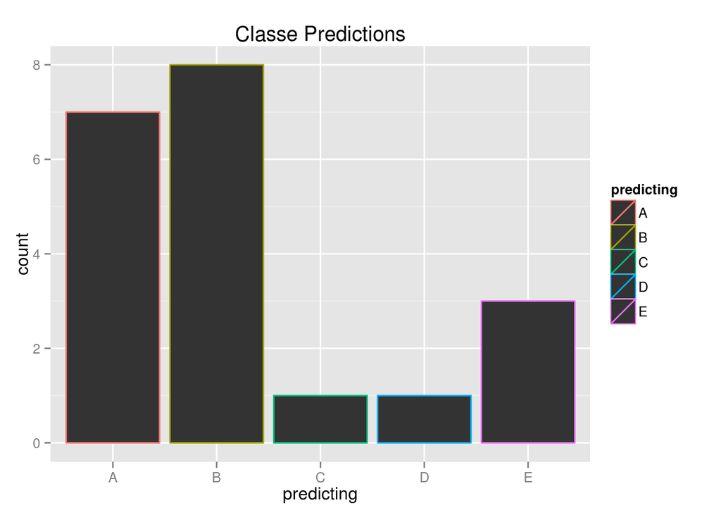

```r
library(ggplot2)
qplot(predicting,colour=predicting,main="Classe Predictions")
```

Exercises exactly according to the specification (Class A). Throwing the elbows to the front (Class B). Lifting the dumbbell only halfway (Class C). Lowering the dumbbell only halfway (Class D). Throwing the hips to the front (Class E).

Class A corresponds to the specified execution of the exercise, while the other 4 classes correspond to common mistakes. Thus, we see 35% participants belong to the Class A and 65% participants belong to the other 4 classes.